# Risk Factors

# Intro

This doc will explore mortality and DALYs by risk factors

First to load the pre requisite packages and script for downloading data.

```r
library(tidyverse)
source("download_completed_request.R")
```

Next I will download the data from the request. (Only has to be done once so now set not to evaluate (run)).

The files can now be loaded and joined locally as follows

```r
dta <- read_csv("raw_data/risk/1.csv") %>% bind_rows(read_csv("raw_data/risk/2.csv"))
dta
```

| measure_id | measure_name | location_id | location_name | sex_id | sex_name | age_id | age_name | cause_id | cause_name | rei_id | rei_name | metric_id | metric_name | year | val | upper | lower |
| --- | --- | --- | --- | --- | --- | --- | --- | --- | --- | --- | --- | --- | --- | --- | --- | --- | --- |
| 2 | DALYs (Disability-Adjusted Life Years) | 1 | Global | 1 | Male | 1 | Under 5 | 294 | All causes | 161 | Occupational exposure to silica | 1 | Number | 1990 | 0.000000e+00 | 0.000000e+00 | 0.000000e+00 |
| 2 | DALYs (Disability-Adjusted Life Years) | 1 | Global | 2 | Female | 1 | Under 5 | 294 | All causes | 161 | Occupational exposure to silica | 1 | Number | 1990 | 0.000000e+00 | 0.000000e+00 | 0.000000e+00 |
| 2 | DALYs (Disability-Adjusted Life Years) | 1 | Global | 1 | Male | 1 | Under 5 | 294 | All causes | 161 | Occupational exposure to silica | 2 | Percent | 1990 | 0.000000e+00 | 0.000000e+00 | 0.000000e+00 |
| 2 | DALYs (Disability-Adjusted Life Years) | 1 | Global | 2 | Female | 1 | Under 5 | 294 | All causes | 161 | Occupational exposure to silica | 2 | Percent | 1990 | 0.000000e+00 | 0.000000e+00 | 0.000000e+00 |
| 2 | DALYs (Disability-Adjusted Life Years) | 1 | Global | 1 | Male | 1 | Under 5 | 294 | All causes | 161 | Occupational exposure to silica | 3 | Rate | 1990 | 0.000000e+00 | 0.000000e+00 | 0.000000e+00 |
| 2 | DALYs (Disability-Adjusted Life Years) | 1 | Global | 2 | Female | 1 | Under 5 | 294 | All causes | 161 | Occupational exposure to silica | 3 | Rate | 1990 | 0.000000e+00 | 0.000000e+00 | 0.000000e+00 |
| 2 | DALYs (Disability-Adjusted Life Years) | 1 | Global | 1 | Male | 22 | All Ages | 294 | All causes | 161 | Occupational exposure to silica | 1 | Number | 1990 | 1.009517e+06 | 1.443868e+06 | 5.921212e+05 |
| 2 | DALYs (Disability-Adjusted Life Years) | 1 | Global | 2 | Female | 22 | All Ages | 294 | All causes | 161 | Occupational exposure to silica | 1 | Number | 1990 | 1.635111e+05 | 2.533036e+05 | 7.801116e+04 |
| 2 | DALYs (Disability-Adjusted Life Years) | 1 | Global | 1 | Male | 22 | All Ages | 294 | All causes | 161 | Occupational exposure to silica | 2 | Percent | 1990 | 7.756577e-04 | 1.112484e-03 | 4.464170e-04 |
| 2 | DALYs (Disability-Adjusted Life Years) | 1 | Global | 2 | Female | 22 | All Ages | 294 | All causes | 161 | Occupational exposure to silica | 2 | Percent | 1990 | 1.428839e-04 | 2.207815e-04 | 6.576166e-05 |

[output cut: 990 more lines]

```r
glimpse(dta)
```

```
Observations: 501,900
Variables: 18
$ measure_id    <int> 2, 2, 2, 2, 2, 2, 2, 2, 2, 2, 2, 2, 2, 2, 2, 2, 2, 2, 2, 2, 2, 2, 2, 2, 2, ...
$ measure_name  <chr> "DALYs (Disability-Adjusted Life Years)", "DALYs (Disability-Adjusted Life ...
$ location_id   <int> 1, 1, 1, 1, 1, 1, 1, 1, 1, 1, 1, 1, 1, 1, 1, 1, 1, 1, 1, 1, 1, 1, 1, 1, 1, ...
$ location_name <chr> "Global", "Global", "Global", "Global", "Global", "Global", "Global", "Glob...
$ sex_id        <int> 1, 2, 1, 2, 1, 2, 1, 2, 1, 2, 1, 2, 1, 2, 1, 2, 1, 2, 1, 2, 1, 2, 1, 2, 1, ...
$ sex_name      <chr> "Male", "Female", "Male", "Female", "Male", "Female", "Male", "Female", "Ma...
$ age_id        <int> 1, 1, 1, 1, 1, 1, 22, 22, 22, 22, 22, 22, 23, 23, 23, 23, 23, 23, 24, 24, 2...
$ age_name      <chr> "Under 5", "Under 5", "Under 5", "Under 5", "Under 5", "Under 5", "All Ages...
$ cause_id      <int> 294, 294, 294, 294, 294, 294, 294, 294, 294, 294, 294, 294, 294, 294, 294, ...
$ cause_name    <chr> "All causes", "All causes", "All causes", "All causes", "All causes", "All ...
$ rei_id        <int> 161, 161, 161, 161, 161, 161, 161, 161, 161, 161, 161, 161, 161, 161, 161, ...
$ rei_name      <chr> "Occupational exposure to silica", "Occupational exposure to silica", "Occu...
$ metric_id     <int> 1, 1, 2, 2, 3, 3, 1, 1, 2, 2, 3, 3, 1, 1, 2, 2, 3, 3, 1, 1, 2, 2, 3, 3, 1, ...
$ metric_name   <chr> "Number", "Number", "Percent", "Percent", "Rate", "Rate", "Number", "Number...
$ year          <int> 1990, 1990, 1990, 1990, 1990, 1990, 1990, 1990, 1990, 1990, 1990, 1990, 199...
$ val           <dbl> 0.000000e+00, 0.000000e+00, 0.000000e+00, 0.000000e+00, 0.000000e+00, 0.000...
$ upper         <dbl> 0.000000e+00, 0.000000e+00, 0.000000e+00, 0.000000e+00, 0.000000e+00, 0.000...
$ lower         <dbl> 0.000000e+00, 0.000000e+00, 0.000000e+00, 0.000000e+00, 0.000000e+00, 0.000...
```

The `_id` suffix columns can be used to join to the lookup tables. In this case for risk (by rei_id)

```r
lookup <- readxl::read_excel("raw_data/IHME_GBD_2016_CODEBOOK/IHME_GBD_2016_REI_HIERARCHY_Y2018M04D26.XLSX")
lookup
```

| rei_id | rei_name | parent_id | level | sort_order |
| --- | --- | --- | --- | --- |
| 169 | All risk factors | 169 | 0 | 1 |
| 202 | Environmental/occupational risks | 169 | 1 | 2 |
| 203 | Behavioral risks | 169 | 1 | 3 |
| 104 | Metabolic risks | 169 | 1 | 4 |
| 171 | Etiologies | 171 | 0 | 5 |
| 191 | Impairments | 191 | 0 | 6 |
| 82 | Unsafe water, sanitation, and handwashing | 202 | 2 | 7 |
| 83 | Unsafe water source | 82 | 3 | 8 |
| 84 | Unsafe sanitation | 82 | 3 | 9 |
| 238 | No access to handwashing facility | 82 | 3 | 10 |

[output cut: 134 more lines]

```r
glimpse(lookup)
```

```
Observations: 144
Variables: 5
$ rei_id     <dbl> 169, 202, 203, 104, 171, 191, 82, 83, 84, 238, 85, 86, 87, 88, 89, 90, 91, 126...
$ rei_name   <chr> "All risk factors", "Environmental/occupational risks", "Behavioral risks", "M...
$ parent_id  <dbl> 169, 169, 169, 169, 171, 191, 202, 82, 82, 82, 202, 85, 85, 85, 202, 89, 89, 2...
$ level      <dbl> 0, 1, 1, 1, 0, 0, 2, 3, 3, 3, 2, 3, 3, 3, 2, 3, 3, 2, 3, 4, 4, 4, 4, 4, 4, 4, ...
$ sort_order <dbl> 1, 2, 3, 4, 5, 6, 7, 8, 9, 10, 11, 12, 13, 14, 15, 16, 17, 18, 19, 20, 21, 22,...
```

In this example I’ll join then filter only level 1 categories in the rei hierarchy

```r
dta %>%
  left_join(lookup) %>%
  filter(level == 1) -> dta_lvl1
```

Now to start exploring: age-standardised, global, deaths, by lvl 1 risk factor and gender

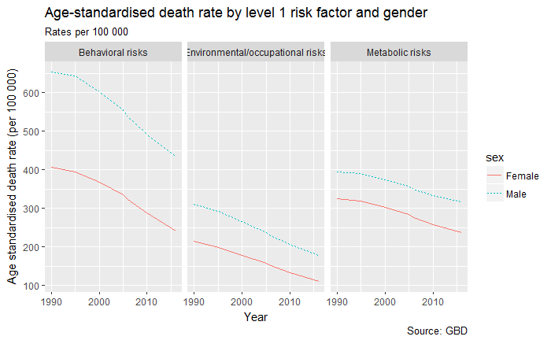

```r
dta_lvl1 %>%
  filter(measure_name == "Deaths") %>%
  filter(location_name == "Global") %>%
  filter(age_name == "Age-standardized") %>%
  filter(metric_name == "Rate") %>%
  filter(cause_name == "All causes") %>%
  select(year, sex = sex_name, risk_factor = rei_name, death_rate = val) %>%
  ggplot(aes(x = year, y = death_rate, linetype = sex, colour = sex)) +
  facet_wrap(~ risk_factor) +
  geom_line() +
  labs(
    x = "Year", y = "Age standardised death rate (per 100 000)",
    title = "Age-standardised death rate by level 1 risk factor and gender",
    subtitle = "Rates per 100 000",
    caption = "Source: GBD"
       )
ggsave("figures/level1_riskfactor_agestandardised.png", width = 20, height = 15, units = "cm", dpi = 300)
```

Now to do the same by SDI

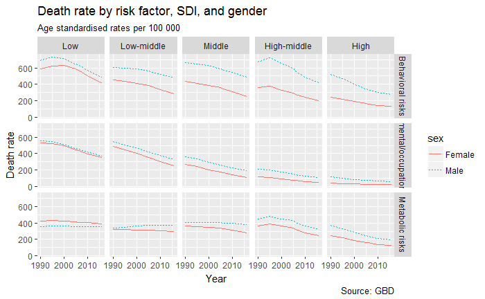

```r
dta_lvl1 %>%
  filter(measure_name == "Deaths") %>%
  filter(location_name != "Global") %>%
  filter(age_name == "Age-standardized") %>%
  filter(metric_name == "Rate") %>%
  filter(cause_name == "All causes") %>%
  select(year, sex = sex_name, sdi = location_name, risk_factor = rei_name, death_rate = val) %>%
  mutate(sdi = stringr::str_replace(sdi, " SDI", "")) %>%
  mutate(sdi = factor(sdi, levels = c("Low", "Low-middle", "Middle", "High-middle", "High"), ordered = T)) %>%
  ggplot(aes(x = year, y = death_rate, linetype = sex, colour = sex)) +
  facet_grid(risk_factor ~ sdi) +
  geom_line() +
  labs(
    x = "Year", y = "Death rate",
    title = "Death rate by risk factor, SDI, and gender",
    subtitle = "Age standardised rates per 100 000",
    caption = "Source: GBD"

  )
ggsave("figures/riskfactor_sdi_gender.png", height = 20, width = 30, units = "cm", dpi = 300)
```

Now to do the same by SDI

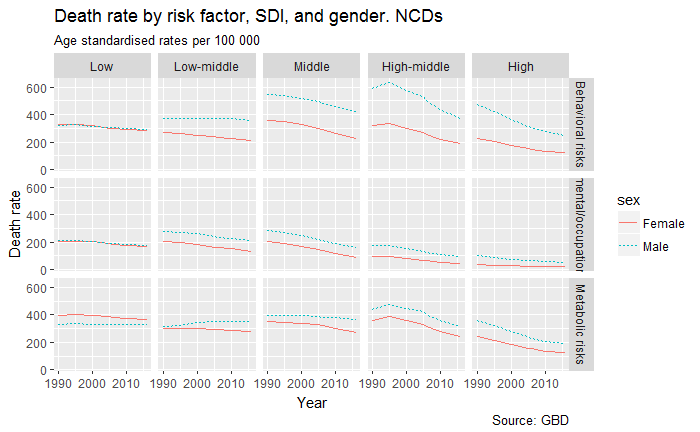

```r
dta_lvl1 %>%
  filter(measure_name == "Deaths") %>%
  filter(location_name != "Global") %>%
  filter(age_name == "Age-standardized") %>%
  filter(metric_name == "Rate") %>%
  filter(cause_name == "Non-communicable diseases") %>%
  select(year, sex = sex_name, sdi = location_name, risk_factor = rei_name, death_rate = val) %>%
  mutate(sdi = stringr::str_replace(sdi, " SDI", "")) %>%
  mutate(sdi = factor(sdi, levels = c("Low", "Low-middle", "Middle", "High-middle", "High"), ordered = T)) %>%
  ggplot(aes(x = year, y = death_rate, linetype = sex, colour = sex)) +
  facet_grid(risk_factor ~ sdi) +
  geom_line() +
  labs(
    x = "Year", y = "Death rate",
    title = "Death rate by risk factor, SDI, and gender. NCDs",
    subtitle = "Age standardised rates per 100 000",
    caption = "Source: GBD"

  )
ggsave("figures/riskfactor_sdi_gender_NCDs.png", height = 20, width = 30, units = "cm", dpi = 300)
```

And now let’s see what this implies for relative inequalities

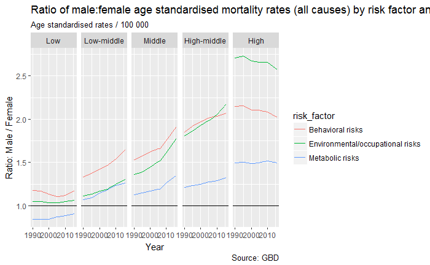

```r
dta_lvl1 %>%
    filter(measure_name == "Deaths") %>%
    filter(location_name != "Global") %>%
    filter(age_name == "Age-standardized") %>%
    filter(metric_name == "Rate") %>%
    filter(cause_name == "All causes") %>%
    select(year, sex = sex_name, sdi = location_name, risk_factor = rei_name, death_rate = val) %>%
    mutate(sdi = stringr::str_replace(sdi, " SDI", "")) %>%
    mutate(sdi = factor(sdi, levels = c("Low", "Low-middle", "Middle", "High-middle", "High"), ordered = T)) %>% spread(sex, death_rate) %>% mutate(ratio = Male / Female) %>%
  ggplot(aes(x = year, y = ratio, colour = risk_factor)) +
  geom_line() +
  facet_grid(. ~ sdi) +
  geom_hline(yintercept = 1) +
  labs(
    x = "Year",
    y = "Ratio: Male / Female",
    title = "Ratio of male:female age standardised mortality rates (all causes) by risk factor and SDI",
    subtitle = "Age standardised rates / 100 000",
    caption = "Source: GBD"
  )
ggsave("figures/ratio_rates_allcause.png", height = 20, width = 20, units = "cm", dpi = 300)
```

As above, but NCDs only

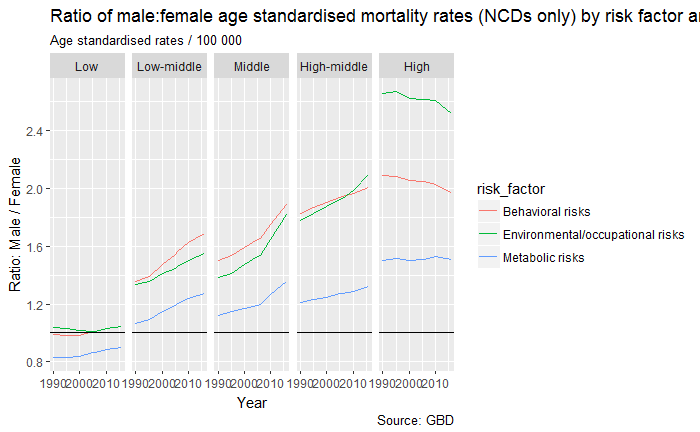

```r
dta_lvl1 %>%
    filter(measure_name == "Deaths") %>%
    filter(location_name != "Global") %>%
    filter(age_name == "Age-standardized") %>%
    filter(metric_name == "Rate") %>%
    filter(cause_name == "Non-communicable diseases") %>%
    select(year, sex = sex_name, sdi = location_name, risk_factor = rei_name, death_rate = val) %>%
    mutate(sdi = stringr::str_replace(sdi, " SDI", "")) %>%
    mutate(sdi = factor(sdi, levels = c("Low", "Low-middle", "Middle", "High-middle", "High"), ordered = T)) %>% spread(sex, death_rate) %>% mutate(ratio = Male / Female) %>%
  ggplot(aes(x = year, y = ratio, colour = risk_factor)) +
  geom_line() +
  facet_grid(. ~ sdi) +
  geom_hline(yintercept = 1) +
  labs(
    x = "Year",
    y = "Ratio: Male / Female",
    title = "Ratio of male:female age standardised mortality rates (NCDs only) by risk factor and SDI",
    subtitle = "Age standardised rates / 100 000",
    caption = "Source: GBD"
  )
ggsave("figures/ratio_rates_ncds.png", height = 20, width = 20, units = "cm", dpi = 300)
```

# DALY decomposition

Let’s look at the contribution of different risk factors to DALY difference

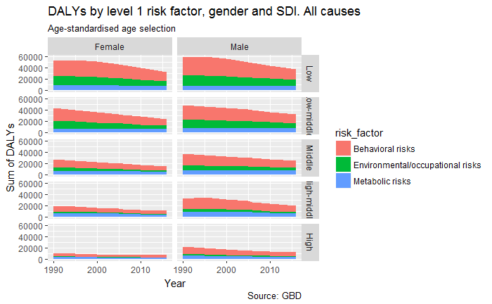

```r
dta_lvl1 %>%
  filter(measure_name == "DALYs (Disability-Adjusted Life Years)") %>%
  filter(location_name != "Global") %>%
  filter(cause_name == "All causes") %>%
  filter(age_name == "Age-standardized") %>%
  filter(metric_name == "Rate") %>%
  select(year, sex = sex_name, sdi = location_name, risk_factor = rei_name, daly_rate = val) %>%
  mutate(sdi = stringr::str_replace(sdi, " SDI", "")) %>%
  mutate(sdi = factor(sdi, levels = c("Low", "Low-middle", "Middle", "High-middle", "High"), ordered = T)) %>%
  ggplot(aes(x = year, y = daly_rate, fill = risk_factor), colour = "black") +
  geom_area() +
  facet_grid(sdi~sex) +
  labs(
    x = "Year",
    y = "Sum of DALYs",
    title = "DALYs by level 1 risk factor, gender and SDI. All causes",
    subtitle = "Age-standardised age selection",
    caption = "Source: GBD"

  )
ggsave("figures/DALYsum_agestandardised_allcauses.png", width = 25, height = 25, units = "cm", dpi = 300)
```

Now proportion of all DALYs attributable to each risk factor by year and SDI

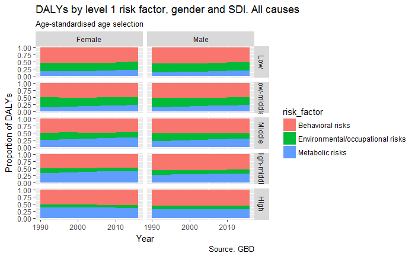

```r
dta_lvl1 %>%
  filter(measure_name == "DALYs (Disability-Adjusted Life Years)") %>%
  filter(location_name != "Global") %>%
  filter(cause_name == "All causes") %>%
  filter(age_name == "Age-standardized") %>%
  filter(metric_name == "Rate") %>%
  select(year, sex = sex_name, sdi = location_name, risk_factor = rei_name, daly_rate = val) %>%
  mutate(sdi = stringr::str_replace(sdi, " SDI", "")) %>%
  mutate(sdi = factor(sdi, levels = c("Low", "Low-middle", "Middle", "High-middle", "High"), ordered = T)) %>%
  group_by(year, sex, sdi) %>%
  mutate(total = sum(daly_rate)) %>%
  mutate(proportion_total = daly_rate / total) %>%
  ungroup() %>%
  ggplot(aes(x = year, y = proportion_total, fill = risk_factor), colour = "black") +
  geom_area() +
  facet_grid(sdi~sex) +
  labs(
    x = "Year",
    y = "Proportion of DALYs",
    title = "DALYs by level 1 risk factor, gender and SDI. All causes",
    subtitle = "Age-standardised age selection",
    caption = "Source: GBD"

  )
ggsave("figures/DALYprop_agestandardised_allcauses.png", width = 25, height = 25, units = "cm", dpi = 300)
```

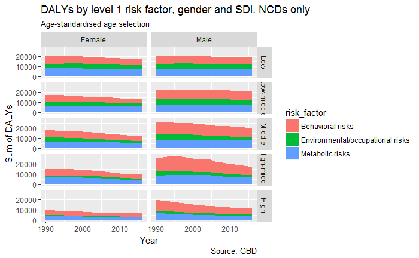

```r
dta_lvl1 %>%
  filter(measure_name == "DALYs (Disability-Adjusted Life Years)") %>%
  filter(location_name != "Global") %>%
  filter(cause_name == "Non-communicable diseases") %>%
  filter(age_name == "Age-standardized") %>%
  filter(metric_name == "Rate") %>%
  select(year, sex = sex_name, sdi = location_name, risk_factor = rei_name, daly_rate = val) %>%
  mutate(sdi = stringr::str_replace(sdi, " SDI", "")) %>%
  mutate(sdi = factor(sdi, levels = c("Low", "Low-middle", "Middle", "High-middle", "High"), ordered = T)) %>%
  ggplot(aes(x = year, y = daly_rate, fill = risk_factor), colour = "black") +
  geom_area() +
  facet_grid(sdi~sex) +
  labs(
    x = "Year",
    y = "Sum of DALYs",
    title = "DALYs by level 1 risk factor, gender and SDI. NCDs only",
    subtitle = "Age-standardised age selection",
    caption = "Source: GBD"

  )
ggsave("figures/DALYsum_agestandardised_NCDs.png", width = 25, height = 25, units = "cm", dpi = 300)
```

Now proportion of all DALYs attributable to each risk factor by year and SDI

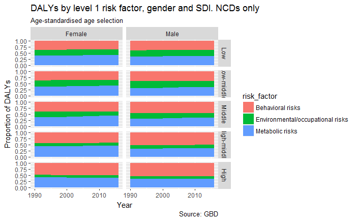

```r
dta_lvl1 %>%
  filter(measure_name == "DALYs (Disability-Adjusted Life Years)") %>%
  filter(location_name != "Global") %>%
  filter(cause_name == "Non-communicable diseases") %>%
  filter(age_name == "Age-standardized") %>%
  filter(metric_name == "Rate") %>%
  select(year, sex = sex_name, sdi = location_name, risk_factor = rei_name, daly_rate = val) %>%
  mutate(sdi = stringr::str_replace(sdi, " SDI", "")) %>%
  mutate(sdi = factor(sdi, levels = c("Low", "Low-middle", "Middle", "High-middle", "High"), ordered = T)) %>%
  group_by(year, sex, sdi) %>%
  mutate(total = sum(daly_rate)) %>%
  mutate(proportion_total = daly_rate / total) %>%
  ungroup() %>%
  ggplot(aes(x = year, y = proportion_total, fill = risk_factor), colour = "black") +
  geom_area() +
  facet_grid(sdi~sex) +
  labs(
    x = "Year",
    y = "Proportion of DALYs",
    title = "DALYs by level 1 risk factor, gender and SDI. NCDs only",
    subtitle = "Age-standardised age selection",
    caption = "Source: GBD"

  )
ggsave("figures/DALYprop_agestandardised_NCDs.png", width = 25, height = 25, units = "cm", dpi = 300)
```

# Prop total deaths attributable to diff risk factors

Now proportion of total deaths

```r
by_factor <- dta_lvl1 %>%
  filter(measure_name == "Deaths") %>%
  select(-measure_name, -measure_id) %>%
  filter(location_name != "Global") %>%
  filter(age_name == "Age-standardized") %>%
  filter(metric_name == "Rate") %>%
  filter(cause_name == "All causes") %>%
  select(year, sex = sex_name, sdi = location_name, rei = rei_name, rate = val) %>%   mutate(sdi = stringr::str_replace(sdi, " SDI", "")) %>%
  mutate(sdi = factor(sdi, levels = c("Low", "Low-middle", "Middle", "High-middle", "High"), ordered = T))
overall <- dta %>%
  filter(rei_name == "All risk factors") %>%
  filter(measure_name == "Deaths") %>%
  select(-measure_name, -measure_id) %>%
  filter(location_name != "Global") %>%
  filter(age_name == "Age-standardized") %>%
  filter(metric_name == "Rate") %>%
  filter(cause_name == "All causes") %>%
  select(year, sex = sex_name, sdi = location_name, rei = rei_name, rate = val) %>%   mutate(sdi = stringr::str_replace(sdi, " SDI", "")) %>%
  mutate(sdi = factor(sdi, levels = c("Low", "Low-middle", "Middle", "High-middle", "High"), ordered = T))
joined <- bind_rows(by_factor, overall)
rm(by_factor, overall)
```

Unfortunately it seems ‘all risk factors’ is not the same as ‘total’, i.e. the absolute differences in age-standardised death rates from each of the three level 1 risk factors do not add up to the ‘all risk factors’ absolute difference

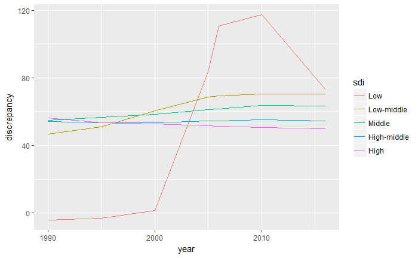

```r
joined %>%
  spread(sex, rate) %>%
  mutate(abs_diff = Male - Female) %>%
  group_by(year, sdi) %>%
  mutate(perc_of_abs_diff = 100 * abs_diff / abs_diff[rei=="All risk factors"]) %>%
  summarise(discrepancy = sum(perc_of_abs_diff[rei != "All risk factors"]) - 100) %>%
  ungroup() %>%
  ggplot(aes(x = year, y = discrepancy, colour = sdi)) +
  geom_line()
```

So, the risk factors might not be mutually exclusive and exhaustive. Let’s take middle SDI in 2000 as an example

```r
joined %>%
  filter(sdi == "Middle") %>%
  filter(year == 2000) %>%
  spread(sex, rate) %>%
  mutate(abs_diff = Male - Female) %>%
  group_by(year, sdi) %>%
  mutate(perc_of_abs_diff = 100 * abs_diff / abs_diff[rei=="All risk factors"])
```

| year | sdi | rei | Female | Male | abs_diff | perc_of_abs_diff |
| --- | --- | --- | --- | --- | --- | --- |
| 2000 | Middle | All risk factors | 609.9048 | 856.5938 | 246.68898 | 100.00000 |
| 2000 | Middle | Behavioral risks | 386.0749 | 626.1121 | 240.03722 | 97.30358 |
| 2000 | Middle | Environmental/occupational risks | 206.0026 | 298.5151 | 92.51256 | 37.50170 |
| 2000 | Middle | Metabolic risks | 346.3842 | 404.9049 | 58.52074 | 23.72248 |

So, the total of the three bottom rows adds up to around 160, when I might expect them to add to 100. A simple decomposition assumption doesn’t seem to apply when using the ‘all risk factors’ designation as total.

To try to account for this let’s look at a different dataset, with:

- Age standardised ages
- All cause
- Mortality rates
- By SDI

Let’s try to grab this data with a new query

The query link is [here](http://ghdx.healthdata.org/gbd-results-tool/result/c9bf1a5197bf46a966c1467c3103e8a9).

```r
url_body <- "http://s3.healthdata.org/gbd-api-2016-production/c9bf1a5197bf46a966c1467c3103e8a9_files"
url_head <- "IHME-GBD_2016_DATA-c9bf1a51-"
outdir <- "raw_data/rate_all_cause"

download_completed_request(url_body, url_head, outdir, flush = T)
```

And now to load this file

```r
dta_total <- read_csv("raw_data/rate_all_cause/1.csv")
```

```r
by_factor <- dta_lvl1 %>%
  filter(measure_name == "Deaths") %>%
  select(-measure_name, -measure_id) %>%
  filter(location_name != "Global") %>%
  filter(age_name == "Age-standardized") %>%
  filter(metric_name == "Rate") %>%
  filter(cause_name == "All causes") %>%
  select(year, sex = sex_name, sdi = location_name, rei = rei_name, rate = val) %>%   mutate(sdi = stringr::str_replace(sdi, " SDI", "")) %>%
  mutate(sdi = factor(sdi, levels = c("Low", "Low-middle", "Middle", "High-middle", "High"), ordered = T))
overall <- dta_total %>% filter(location != "Global") %>% mutate(rei = "total") %>% mutate(sdi = stringr::str_replace(location, " SDI", "")) %>%
    mutate(sdi = factor(sdi, levels = c("Low", "Low-middle", "Middle", "High-middle", "High"), ordered = T)) %>% select(year, sex, sdi, rei, rate = val)
```

Let’s see if the totals add up this time. The three level 1 risk factors are shown as stacked areas, and the total is shown as a black line…

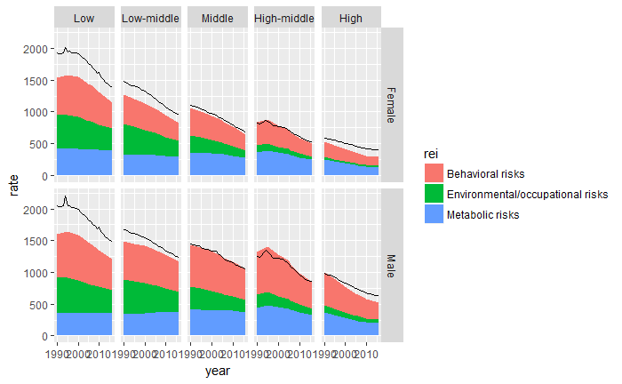

```r
by_factor %>%
  ggplot(aes(x = year, y = rate, fill = rei)) +
  geom_area() +
  facet_grid(sex ~ sdi) +
  geom_line(aes(x = year, y = rate), inherit.aes = F, data = overall)
```

So, there is still discrepancy, which seems to be largest for low SDI, and smallest for high-middle SDI, but this might be decomposable subject to some assumptions.

Let’s now compare with previous attempt at an ‘overall’ estimate (based on ‘all risk factors’). In the following this is added as a black dashed line. We might expect the dashed and solid lines to be the same, but are they?

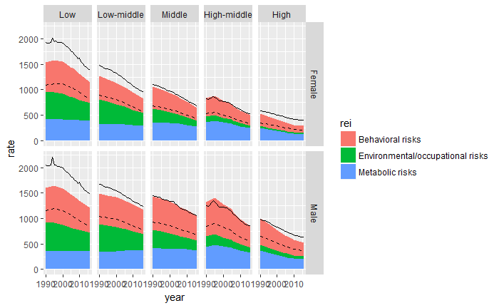

```r
overall2 <- dta %>%
  filter(rei_name == "All risk factors") %>%
  filter(measure_name == "Deaths") %>%
  select(-measure_name, -measure_id) %>%
  filter(location_name != "Global") %>%
  filter(age_name == "Age-standardized") %>%
  filter(metric_name == "Rate") %>%
  filter(cause_name == "All causes") %>%
  select(year, sex = sex_name, sdi = location_name, rei = rei_name, rate = val) %>%   mutate(sdi = stringr::str_replace(sdi, " SDI", "")) %>%
  mutate(sdi = factor(sdi, levels = c("Low", "Low-middle", "Middle", "High-middle", "High"), ordered = T))
by_factor %>%
  ggplot(aes(x = year, y = rate, fill = rei)) +
  geom_area() +
  facet_grid(sex ~ sdi) +
  geom_line(aes(x = year, y = rate), inherit.aes = F, data = overall) +
  geom_line(aes(x = year, y = rate), inherit.aes = F, data = overall2, linetype = "dashed")
```

So, there are clear differences between age-standardised rates drawn from all causes (solid line), and age-standardised rates drawm from all risk factors (dashed lines), with the latter below the former. Again, this raises questions about how to perform a decomposition into risk factors, the effect of age-standardization, and so on.

# Level 1 internal decomposition

Let’s not use level 0 for decomposing level 1 etc, and instead just produce estimates of total by summing up level 1 risks. Then, do the same for level 2.

```r
contributions <- by_factor %>%
  inner_join(
    by_factor %>%
      group_by(year, sex, sdi) %>%
      summarise(total_rate = sum(rate)) %>%
      ungroup()
    ) %>%
  group_by(year, sdi) %>%
  mutate(abs_sex_diff = total_rate[sex == "Male"][1] - total_rate[sex == "Female"][1]) %>%
  group_by(year, sdi, rei) %>%
  mutate(rei_abs_sex_diff = rate[sex == "Male"] - rate[sex == "Female"]) %>%
  ungroup() %>%
  mutate(contribution = 100 * rei_abs_sex_diff / abs_sex_diff)
```

Now to plot the contribution over time by SDI

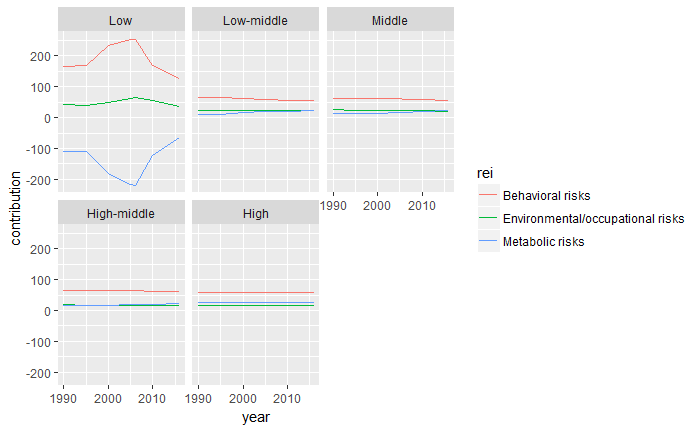

```r
contributions %>%
  select(year, sex, sdi, rei, contribution) %>%
  distinct() %>%
  ggplot(aes(x = year, y= contribution, colour = rei)) +
  geom_line() +
  facet_wrap(~sdi)
```

Let’s think again about how to present this in the case of three risk factors, such that it could be scaled up to more factors

```r
by_factor %>%
  spread(sex, rate) %>%
  mutate(diff_abs = Male - Female) %>%
  group_by(year, sdi) %>%
  mutate(diff_cumulative = cumsum(diff_abs)) -> cumulative_contributions
```

Now to plot for two years, 1990 and 2010

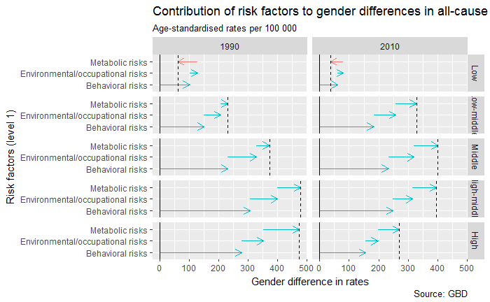

```r
# use geom_segement
cumulative_contributions %>%
    filter(year %in% c(1990, 2010)) %>%
    mutate(start_pos = diff_cumulative - diff_abs) %>%
    mutate(is_increasing = diff_cumulative > start_pos) %>%
  group_by(year, sdi) %>%
  mutate(max_cumulative = diff_cumulative[length(diff_cumulative)]) %>%
  ungroup() %>%
  ggplot(aes(x = start_pos, xend = diff_cumulative, y = rei, yend = rei, colour = is_increasing)) +
  geom_segment( arrow = arrow(length = unit(0.2, "npc"))) +
  facet_grid(sdi ~ year) +
  geom_vline(xintercept = 0) +
  geom_vline(aes(xintercept = max_cumulative), linetype = "dashed") +
  guides(colour = FALSE) +
  labs(x = "Gender difference in rates", y = "Risk factors (level 1)", title = "Contribution of risk factors to gender differences in all-cause mortality rates", subtitle = "Age-standardised rates per 100 000", caption = "Source: GBD")
ggsave("figures/contribution_of_level1_riskfactors_death_rate.png", height = 30, width = 30, units = "cm", dpi = 300)
```

This seems to work as a visualisation. Let’s try to scale up to level 2

```r
by_factor_l2 <- dta %>%
  left_join(lookup) %>%
  filter(level == 2)  %>%
  filter(measure_name == "Deaths") %>%
  select(-measure_name, -measure_id) %>%
  filter(location_name != "Global") %>%
  filter(age_name == "Age-standardized") %>%
  filter(metric_name == "Rate") %>%
  filter(cause_name == "All causes") %>%
  select(year, sex = sex_name, sdi = location_name, rei = rei_name, rate = val) %>%   mutate(sdi = stringr::str_replace(sdi, " SDI", "")) %>%
  mutate(sdi = factor(sdi, levels = c("Low", "Low-middle", "Middle", "High-middle", "High"), ordered = T))
```

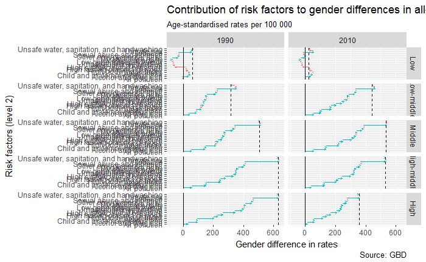

```r
by_factor_l2 %>%
  spread(sex, rate) %>%
  mutate(diff_abs = Male - Female) %>%
  group_by(year, sdi) %>%
  mutate(diff_cumulative = cumsum(diff_abs)) %>%
    filter(year %in% c(1990, 2010)) %>%
    mutate(start_pos = diff_cumulative - diff_abs) %>%
    mutate(is_increasing = diff_cumulative > start_pos) %>%
  group_by(year, sdi) %>%
  mutate(max_cumulative = diff_cumulative[length(diff_cumulative)]) %>%
  ungroup() %>%
  ggplot(aes(x = start_pos, xend = diff_cumulative, y = rei, yend = rei, colour = is_increasing)) +
  geom_segment( arrow = arrow(length = unit(0.05, "npc"))) +
  facet_grid(sdi ~ year) +
  geom_vline(xintercept = 0) +
  geom_vline(aes(xintercept = max_cumulative), linetype = "dashed") +
  guides(colour = FALSE) +
  labs(x = "Gender difference in rates", y = "Risk factors (level 2)", title = "Contribution of risk factors to gender differences in all-cause mortality rates", subtitle = "Age-standardised rates per 100 000", caption = "Source: GBD")
ggsave("figures/contribution_of_level2_riskfactors_death_rate.png", height = 30, width = 30, units = "cm", dpi = 300)
```

This seems to work pretty well though is perhaps at the limit of visual complexity. More time periods etc would likely make this image too busy.

Let’s do the above for NCDs only

Let’s think again about how to present this in the case of three risk factors, such that it could be scaled up to more factors

```r
by_factor <- dta_lvl1 %>%
  filter(measure_name == "Deaths") %>%
  select(-measure_name, -measure_id) %>%
  filter(location_name != "Global") %>%
  filter(age_name == "Age-standardized") %>%
  filter(metric_name == "Rate") %>%
  filter(cause_name == "Non-communicable diseases") %>%
  select(year, sex = sex_name, sdi = location_name, rei = rei_name, rate = val) %>%   mutate(sdi = stringr::str_replace(sdi, " SDI", "")) %>%
  mutate(sdi = factor(sdi, levels = c("Low", "Low-middle", "Middle", "High-middle", "High"), ordered = T))
overall <- dta_total %>% filter(location != "Global") %>% mutate(rei = "total") %>% mutate(sdi = stringr::str_replace(location, " SDI", "")) %>%
    mutate(sdi = factor(sdi, levels = c("Low", "Low-middle", "Middle", "High-middle", "High"), ordered = T)) %>% select(year, sex, sdi, rei, rate = val)
by_factor %>%
  spread(sex, rate) %>%
  mutate(diff_abs = Male - Female) %>%
  group_by(year, sdi) %>%
  mutate(diff_cumulative = cumsum(diff_abs)) -> cumulative_contributions
```

Now to plot for two years, 1990 and 2010

[figure not shown]

```r
# use geom_segement
cumulative_contributions %>%
    filter(year %in% c(1990, 2010)) %>%
    mutate(start_pos = diff_cumulative - diff_abs) %>%
    mutate(is_increasing = diff_cumulative > start_pos) %>%
  group_by(year, sdi) %>%
  mutate(max_cumulative = diff_cumulative[length(diff_cumulative)]) %>%
  ungroup() %>%
  ggplot(aes(x = start_pos, xend = diff_cumulative, y = rei, yend = rei, colour = is_increasing)) +
  geom_segment( arrow = arrow(length = unit(0.2, "npc"))) +
  facet_grid(sdi ~ year) +
  geom_vline(xintercept = 0) +
  geom_vline(aes(xintercept = max_cumulative), linetype = "dashed") +
  guides(colour = FALSE) +
  labs(x = "Gender difference in rates", y = "Risk factors (level 1)", title = "Contribution of risk factors to gender differences in NCD mortality rates", subtitle = "Age-standardised rates per 100 000", caption = "Source: GBD")
ggsave("figures/contribution_of_level1_riskfactors_death_rate_NCDs.png", height = 30, width = 30, units = "cm", dpi = 300)
```

This seems to work as a visualisation. Let’s try to scale up to level 2

```r
by_factor_l2 <- dta %>%
  left_join(lookup) %>%
  filter(level == 2)  %>%
  filter(measure_name == "Deaths") %>%
  select(-measure_name, -measure_id) %>%
  filter(location_name != "Global") %>%
  filter(age_name == "Age-standardized") %>%
  filter(metric_name == "Rate") %>%
  filter(cause_name == "Non-communicable diseases") %>%
  filter(rei_name != "Unsafe sex") %>%
  select(year, sex = sex_name, sdi = location_name, rei = rei_name, rate = val) %>%   mutate(sdi = stringr::str_replace(sdi, " SDI", "")) %>%
  mutate(sdi = factor(sdi, levels = c("Low", "Low-middle", "Middle", "High-middle", "High"), ordered = T))
```

[figure not shown]

```r
by_factor_l2 %>%
  spread(sex, rate) %>%
  mutate(diff_abs = Male - Female) %>%
  group_by(year, sdi) %>%
  mutate(diff_cumulative = cumsum(diff_abs)) %>%
    filter(year %in% c(1990, 2010)) %>%
    mutate(start_pos = diff_cumulative - diff_abs) %>%
    mutate(is_increasing = diff_cumulative > start_pos) %>%
  group_by(year, sdi) %>%
  mutate(max_cumulative = diff_cumulative[length(diff_cumulative)]) %>%
  ungroup() %>%
  ggplot(aes(x = start_pos, xend = diff_cumulative, y = rei, yend = rei, colour = is_increasing)) +
  geom_segment( arrow = arrow(length = unit(0.05, "npc"))) +
  facet_grid(sdi ~ year) +
  geom_vline(xintercept = 0) +
  geom_vline(aes(xintercept = max_cumulative), linetype = "dashed") +
  guides(colour = FALSE) +
  labs(x = "Gender difference in rates", y = "Risk factors (level 2)", title = "Contribution of risk factors to gender differences in NCD mortality rates", subtitle = "Age-standardised rates per 100 000", caption = "Source: GBD")
ggsave("figures/contribution_of_level2_riskfactors_death_rate_NCDs.png", height = 30, width = 30, units = "cm", dpi = 300)
```